# NFL Wins Regression Project

## Sub-setting Data

My two .csv files are not enough for the analysis I want to do, I need to subset the data so I can get the first n games from a team into one row of a new data set and combine the total season wins with the appropriate team, year. I had to be careful with how I made this function since the number of games has increased since the beginning of the NFL, so I added logic to ignore a specific team, year if they do not have at least n games played that season. This results in my data set with more than 12 games having fewer entries.

```r
getNWeeks <- function(n, wins, games) {

  nWeeks <- as.data.frame(matrix(nrow = 0, ncol = 29))
  colnames(nWeeks) = c("Team", "Year", "Tm", "Opp", "Pass.Cmp", "Pass.Att", "Pass.Yds", "Pass.TD", "Int", "Sk", "Sk.Yds", "Pass.Y.A", "Pass.NY.A", "Cmp.", "Rush.Rate", "Rush.Att", "Rush.Yds", "Rush.Y.A", "Rush.TD", "FGM", "FGA", "XPM", "XPA", "Pnt", "Pnt.Yds", "L", "W", "T", "Wins")

  # temp df with col names
  tempS <- nWeeks[0,]
  # df to change vector of "W", "L", or "T" into non categorical data
  wlt <- as.data.frame(matrix(nrow = 1, ncol = 3))
  colnames(wlt) = c('L', 'T', 'W')

  for (i in rownames(wins)) {
    # subset only the rows for the specific team, year
    tempS = games[intersect(which(games$Team == wins[i,1]), which(games$Year == wins[i,3])),]
    # subset only the first n games in a season
    tempS = tempS[1:n,]
    tempS <- tempS[!is.na(tempS[,1]),]

    # the number of games each season changes I don't want to only use data of a team
    # with less games than n
    if (nrow(tempS) >= n){
      # transform vector of W,L,T values to table of wins, losses, and ties
      wlt = rbind.fill(as.data.frame(t(as.matrix(table(tempS$W.L)))),wlt[-1,])
      wlt[is.na(wlt)] <- 0

      # getting the sum of all numeric rows
      rowToAdd <- colSums(tempS[3:25])
      # converting sums of averages back to averages
      rowToAdd[c(9:12,16)] = rowToAdd[c(9:12,16)] / n
      #add win loss tie
      rowToAdd = cbind(as.data.frame(t(as.matrix(rowToAdd))), wlt)
      #add name and year
      rowToAdd = cbind(rowToAdd, tempS[1, c(26,27)])

      #add row to dataframe
      nWeeks <- rbind(nWeeks, rowToAdd)

    }
  }
  return(merge(nWeeks, wins, by = c("Team", "Year")))
}
```

## Regression Functions

Now that my data is subset correctly I can make and refine my models. I do this with the help of 4 different functions makeNFLModel makes the initial model, residCheck checks the residuals, mlcCheck checks for Multicollinearity, and sigCheck checks for significance. I put all these functions into one function so I can make my models in one step.

```r
#function to make the fist model with backwards step wise regression
makeNFLModel <- function(weeksdf){

  model <- lm(Wins ~ Tm + Opp + Pass.Cmp + Pass.Att + Pass.Yds + Pass.TD + Int +
              Sk + Sk.Yds + Pass.Y.A + Pass.NY.A + Cmp. + Rush.Rate + Rush.Att +
              Rush.Yds + Rush.Y.A + Rush.TD + FGM + FGA + XPM + XPA + Pnt +
              Pnt.Yds + L + W + T, data = weeksdf)
  #returns a backwards model
  return(step(model, direction = 'backward', trace = 0))
}

#check the residuals for normality
residCheck <- function(backModel, name){
  res <- resid(backModel)
  qqnorm(res)
  qqline(res)
  plot(density(res), main = paste(paste("Residual Density Curve for first", name), "weeks"))
}


#check Multicollinearity and remove vars
mlcCheck <- function(model, weeksdf) {
  #check variance inflation factor for multicollinearity
  all_vifs <- car::vif(model)
  signif_all <- names(all_vifs)


  while(any(all_vifs > 4)){
    var_with_max_vif <- names(which(all_vifs == max(all_vifs))) # get var with max vif
    signif_all <- signif_all[!(signif_all) %in% var_with_max_vif] # remove
    myForm <- as.formula(paste("Wins ~ ", paste(signif_all, collapse="+"), sep = "")) # new formula
    selectedMod <- lm(myForm, data = weeksdf) #rebuild new style
    all_vifs <- car::vif(selectedMod)}

  return(selectedMod)
}

#last check for significance
sigCheck <- function(model, weeksdf) {
  all_vars <- names(model[[1]])[-1]
  summ <- summary(model)
  pvals <- summ[[4]][,4] # get p values
  not_sig <- character()
  not_sig <- names(which(pvals > 0.1))

  #if all vars are significant does not execute the while loop and return original model
  if(length(not_sig) == 0){
    return(model)
  }

  while(length(not_sig > 0)) {
    all_vars <- all_vars[!all_vars %in% not_sig[1]]
    myForm <- as.formula(paste("Wins ~ ", paste(all_vars, collapse=" + "), sep = ""))
    signif <- lm(myForm, data = weeksdf)

    summ <- summary(signif)
    pvals <- summ[[4]][,4]
    not_sig <- character()
    not_sig <- names(which(pvals > 0.1))
    not_sig <- not_sig[!not_sig %in% "(Intercept)"]
  }

  return(signif)
}

# function to do it all
NFLRegression <- function(weeksdf) {
  m1 <- makeNFLModel(weeksdf)
  residCheck(m1, deparse(substitute(weeksdf)))
  m2 <- mlcCheck(m1, weeksdf)
  m3 <- sigCheck(m2, weeksdf)
  return(m3)
}
```

## Making the Models

Now I get to make my models!

```r
# reading initial data
games <- read.csv(here("NFL Data Unprocessed.csv"))
wins <- read.csv(here("NFL wins.csv"))

models <- list()
for (i in 1:17) {
  #subsets the data and outputs that into the regression functions
  models[[i]] <- NFLRegression(getNWeeks(i, wins, games))
}
```

I have to manually review how normal each plot is, and in my data, the last four data sets start to have non normal residuals. This is partly true because there are much fewer games in those data sets since the number of games has increased since the start of the NFL.

## Reviewing Results

Now that I have every model made I can make the predictions after I get data to predict. Reusing my code from earlier made this process easy, and I was able to use my function getNWeeks without changing anything.

```r
#ls for last season
ls <- get_season(2023)
ls$Team <- gsub('[^[:alnum:] ]', '', ls$Team)
ls <- ls[,c(1,2,16)]
colnames(ls)[2] = "Wins"
ls = ls[order(ls$Team),]

#getting sample data for the model
wins <- data.frame(matrix(ncol = 3))
colnames(wins) <- c("Team", "Wins", "Year")
lsSamp <- data.frame(matrix(ncol = 27))
colnames(lsSamp) = c("Week", "W.L", "Tm", "Opp","Pass.Cmp", "Pass.Att", "Pass.Yds", "Pass.TD", "Int",
                 "Sk", "Sk.Yds", "Pass.Y.A", "Pass.NY.A", "Cmp.", "Rush.Rate", "Rush.Att", "Rush.Yds",
                 "Rush.Y.A", "Rush.TD", "FGM", "FGA", "XPM", "XPA", "Pnt", "Pnt.Yds",
                 "Year", "Team")

# same for loop as in data-mining it just doesn't have the outer loop for every year
for (team in ls$Team) {
  if(is.na(lsSamp[1,1])){
    lsSamp = lsSamp[-1,]
  }

  url <- paste("https://www.pro-football-reference.com/teams/" , team_hrefs[team] , "/2023/gamelog/", sep = '')
  url %>%
    read_html %>%
    html_table() -> df # gets table from html
  tempSeason <- as.data.frame(df[[1]]) # converts to data frame
  tempSeason <- tempSeason[c(1,5,9:31)] # gets rid of data I can't use in a linear model
  tempSeason$year <- 2023 #adds year
  tempSeason$team <- team # adds team name to data
  colnames(tempSeason) = colnames(lsSamp)

  lsSamp <- rbind(lsSamp, tempSeason[-1,])
  Sys.sleep(3) # more than 20 requests per minute puts me in jail
}

# convert datatype to numeric
lsSamp[,c(1,3:26)] <- sapply(lsSamp[,c(-2,-27)], as.numeric)
```

I have two data sets that mimic the allGames and win. lsSamp is last season sample and ls is equivalent to wins.

```r
########## Finally making the predictions!! #######
predictions <- matrix(nrow = 17, ncol = 32)
for (i in 1:17) {
  temp <- getNWeeks(i,ls,lsSamp)
  temp <- predict.lm(models[[i]],temp)
  predictions[i,] = temp
}
```

## Analysis

The two measures of predictors I use are accuracy and RMSE. RMSE stands for root mean square error and this is calculated with the formula $\sqrt{1/n(\sum{(\hat{Y} - Y)^2})}$. This is a lot to look at and understand so I will break it down a bit. The innermost part of it is the predicted value minus the actual value squared. Squaring this value is important because it is always positive now. Then you take the average value for all the squared errors and the square root of that is your MRSE. This measures the effectiveness of a predictor, where a lower MRSE shows a better predictor.

To find the accuracy I round down every value of my squared error count the number of values that are 0 and divide that by the total amount of values.

Before I graph anything I need to generate the data I just mentioned.

```r
sqerror <- t(apply(predictions, 1, function(x) (x - ls$Wins)^2))

#RMSE for each week and each team
weekrmse <- apply(sqerror, 1, function(x) sqrt(sum(x) / 32))
teamrmse <- apply(sqerror, 2, function(x) sqrt(sum(x) / 17))

# accuracy of predictions for each week, team
accW <- apply(floor(sqerror), 1, function(x) length(which(x == 0))) / 32
accT <- apply(floor(sqerror), 2, function(x) length(which(x == 0))) / 17

teamPredict <- cbind(teamrmse, accT, ls[,1:2])
weekPredict <- as.data.frame(cbind(weekrmse, accW, 1:17))
colnames(weekPredict)[3] = "week"
```

Here are the graphs I made.

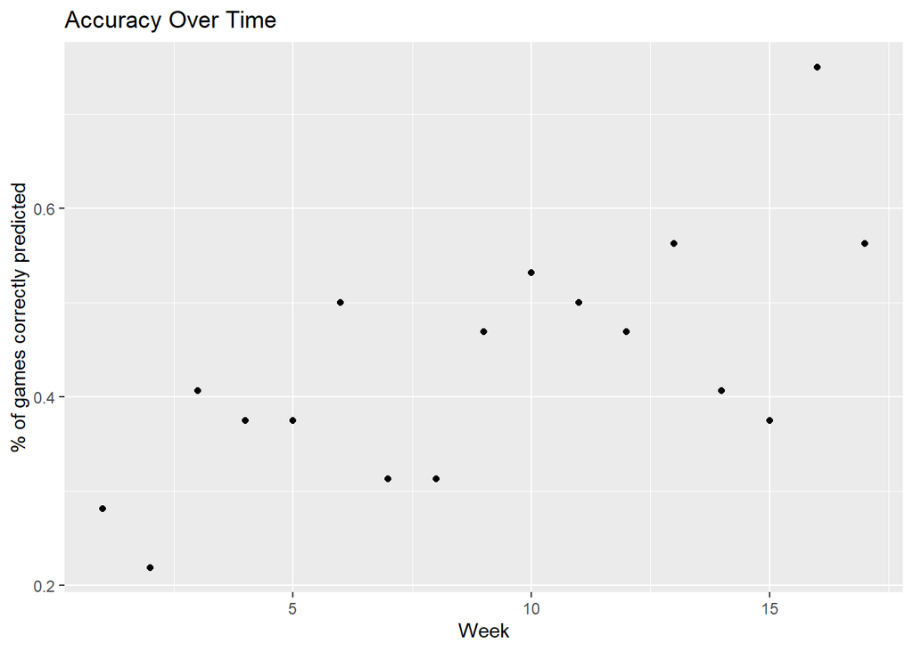

```r
ggplot(weekPredict, aes(x = week, y = accW)) +
  geom_point() +
  labs(x = "Week",
       y = "% of games correctly predicted",
       title = "Accuracy Over Time")
```

Here is Accuracy over the weeks, the trends show that the models get better as they are getting more data. There seems to be more spread in the last few weeks of the data, but again those have less data to train on.

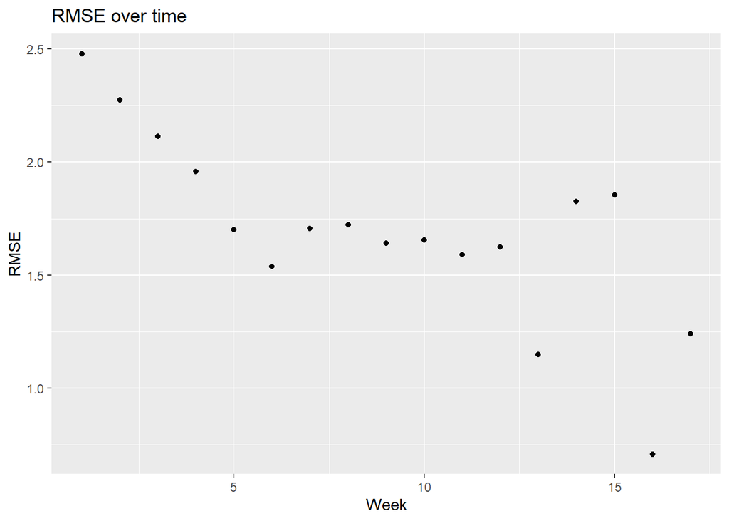

```r
ggplot(weekPredict, aes(x = week, y = weekrmse)) +
  geom_point() +
  labs(x = "Week",
       y = "RMSE",
       title = "RMSE over time")
```

This is RMSE for each model, you can see from this graph that it is decreasing which shows that the predictions are improving. While the last few models have the best RMSE, there is more variation from having less data.

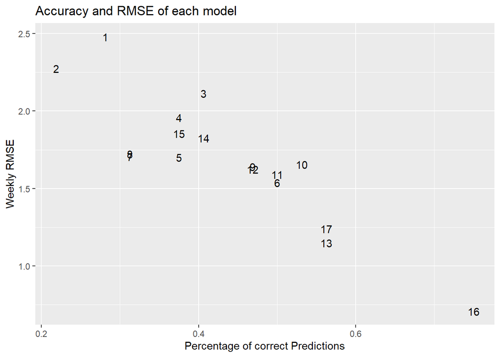

```r
ggplot(weekPredict, aes(x = accW, y = weekrmse)) +
  geom_text(aes(label = week)) +
  labs(x = "Percentage of correct Predictions",
       y = "Weekly RMSE",
       title = "Accuracy and RMSE of each model")
```

[figure not shown]

```r
ggplot(teamPredict, aes(x = accT, y = teamrmse)) +
  nflplotR::geom_nfl_logos(aes(team_abbr = team_hrefs[Team]), width = 0.055, alpha = 0.7) +
  ggplot2::labs(x = "Percentage of Correct Predictions",
                y = "Team RMSE",
                title = "Accuracy and RMSE of Team Predictors")
```

My graph that includes the NFL icons does not tell us a whole lot about how well the models predict, but it is fun to look at which teams were easiest to predict. The MRSE and Accuracy are made using the results of the 17 models and averaging it out by team. The graph shows that the Jacksonville Jaguars had the most success with this model, while it just could not figure out what the Chargers were doing. This graph does show that there is some relation between accuracy and RMSE.

## Conclusion

This project accomplished its goal of showing that predictive models are better as they get more data. I was very interested in the first six weeks, each model’s RMSE got better at a nearly linear rate, then plateaued before the scatter of having less data to train the model.

Overall I am very happy with how this project turned out I was able to show what I wanted, and I learned a lot during the process. I have been coding in R for 4 years but every project has new packages to learn and new skills to try. I think where this project could be improved upon is getting even more data into the model, I did not include categorical data in my model because it is difficult to handle, but maybe you could factor the other team they are playing into the model. The other place for expansion in this project would be predicting if teams will make it to the playoffs with similar data.

Thank you for taking the time to explore my project. I’ve put in a lot of hard work while searching for a data analyst or statistician role. If you’re impressed by my work, I’d love to talk about how I can bring the same dedication and quality to your team.